# Size matters: using machine learning techniques to predict the age of abalone from different measures of size

# Linear Regression - Sean

## Model 1

For the linear regression based models, we being with creating a model based upon all the factors in the data set. This is to generate a base model to improve upon, and to determine which features are the most significant.

```r
fit_lm = lm(Age ~ Sex + Length + Diameter + Height + Weight_W + Weight_Shk + Weight_V + Weight_Shl, data=tr_dat)
```

Next in order to determine the effectiveness of the model, we will calculate the Root Mean Square Error (RMSE) of the model based off its predictions of the testing data.

```r
predicted1 <- predict(fit_lm, te_dat)
actual <- te_dat$Age

rmse1 = sqrt(mean((actual - predicted1)^2))
```

The calculated RMSE value is 2.223788. We will use this value to compare to the RMSE rate of the future models we create to determine their effectiveness.

### Diagnostic Plots

#### Cross Validation

We can preform cross validation upon this model to determine an average RMSE value for the model as a whole. We can also use the histogram derived from this cross validation to compare models against each other.

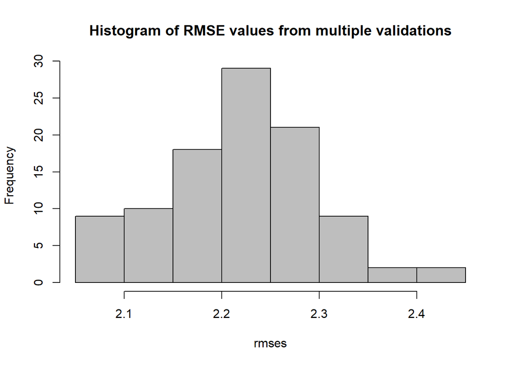

```r
split_data = function(dat, frac=c(0.75, 0.25)) {
  # at least one set must be specified
  k = length(frac)
  stopifnot(k > 0)

  n = nrow(dat)
  frac = frac/(sum(frac))
  starts = c(1, round(cumsum(frac) * n)[-k])
  ends = c(starts[-1]-1,n)
  samp = sample(1:n)
  data_sets = list()
  for (i in 1:k) {
    data_sets[[i]] = dat[samp[starts[i]:ends[i]],]
  }
  return(data_sets)
}

rmses = c()
for (i in 1:100) {
  dsets = split_data(dat, c(2, 1, 1))
  train_dat = dsets[[1]]
  valid_dat = dsets[[2]]

  fit = lm(Age ~ Sex + Length + Diameter + Height + Weight_W + Weight_Shk + Weight_V + Weight_Shl, data=train_dat)

  predicted <- predict(fit, valid_dat)
  actual <- valid_dat$Age
  rmse <- sqrt(mean((actual - predicted)^2))

  rmses = c(rmses, rmse)
}

hist(rmses, col = "grey", main="Histogram of RMSE values from multiple validations")
```

#### Double Density Plot

We can create a density plot of our predictions from the model versus the actual values in the test data in order to visualize how the predictions compare to the actual data.

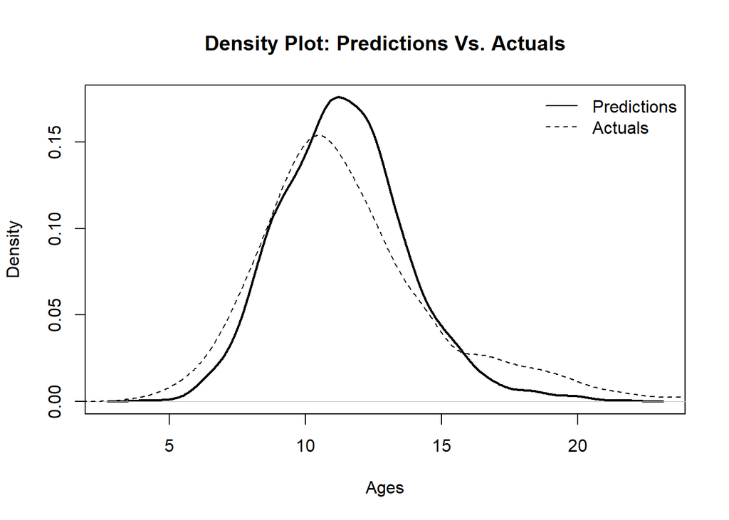

```r
plot(density(predicted1), type="l", lwd=2, xlab="Ages", ylab="Density", main = "Density Plot: Predictions Vs. Actuals")
lines(density(actual), type = "l", lty = 2)
legend("topright", legend = c("Predictions", "Actuals"), lty = c(1,2), bty = "n")
```

#### Learning Curve

The final diagnostic plot we can create is a learning curve of the model. This will show us how, as the size of the training set data increases, the RMSE value of our model changes. A learning curve will also show us if the model shows high bias or high variance in regards to the data.

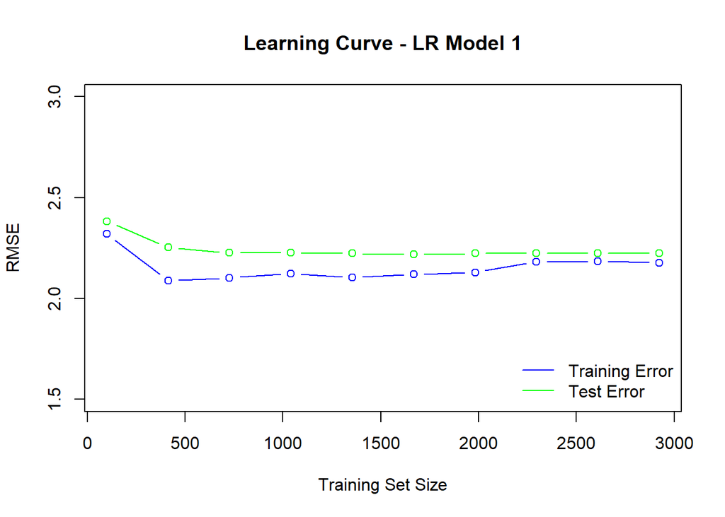

```r
te_errs = c()
tr_errs = c()
te_actual = te_dat$Age
tr_sizes = seq(100, nrow(tr_dat), length.out=10)


for (tr_size in tr_sizes) {
  tr_dat1 = tr_dat[1:tr_size,]
  tr_actual = tr_dat1$Age
  fit = lm(Age ~ Sex + Length + Diameter + Height + Weight_W + Weight_Shk + Weight_V + Weight_Shl, data=tr_dat1)

  # error on training set
  tr_predicted = predict(fit, tr_dat1)
  err = sqrt(mean((tr_actual-tr_predicted)^2))
  tr_errs = c(tr_errs, err)

  # error on test set
  te_predicted = predict(fit, te_dat)
  err = sqrt(mean((te_actual-te_predicted)^2))
  te_errs = c(te_errs, err)
}

plot(tr_sizes, tr_errs,  col="blue", main= "Learning Curve - LR Model 1", type="b",ylim=c(1.5,3), ylab = "RMSE",xlab = "Training Set Size")
lines(tr_sizes,te_errs, col="green", type="b", xlab = "Training Set Size")
legend("bottomright", c("Training Error","Test Error"), col= c("blue","green"), lty=1,bty="n")
```

From the learning curve, we can see that the model exhibts very high bias, however this makes sense as a majority of the features of the data set are highly correlated as they are features of an organism.

## Model 2

```r
fit2_lm = lm(Age ~ Diameter + Height + Weight_W + Weight_Shk + Weight_V + Weight_Shl, data=tr_dat)
```

Next we will generate the predictions from our new model and calculate the RMSE value for it.

```r
predicted2 <- predict(fit2_lm, te_dat)
actual <- te_dat$Age

rmse2 = sqrt(mean((actual - predicted2)^2))
```

With an RMSE value of 2.2445369 we can see that this model has a slightly higher RMSE value as compared to the base model. This would indicate that this second model preforms slightly worse than the base.

### Diagnostic Plots

#### Cross Validation

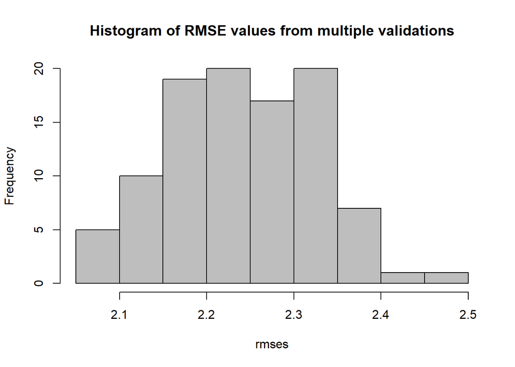

```r
rmses = c()
for (i in 1:100) {
  dsets = split_data(dat, c(2, 1, 1))
  train_dat = dsets[[1]]
  valid_dat = dsets[[2]]

  fit = lm(Age ~ Diameter + Height + Weight_W + Weight_Shk + Weight_V + Weight_Shl, data=train_dat)

  predicted <- predict(fit, valid_dat)
  actual <- valid_dat$Age
  rmse <- sqrt(mean((actual - predicted)^2))

  rmses = c(rmses, rmse)
}

hist(rmses, col="grey", main="Histogram of RMSE values from multiple validations")
```

#### Double Density Plot

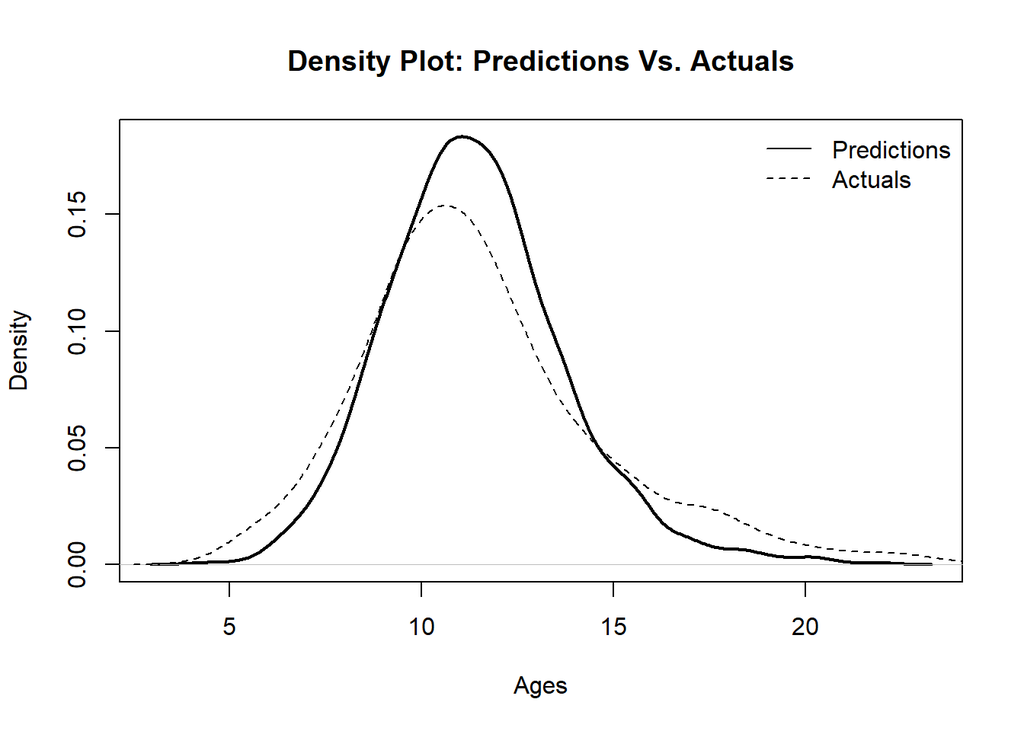

```r
plot(density(predicted2), type="l", lwd=2, xlab="Ages", ylab="Density", main = "Density Plot: Predictions Vs. Actuals")
lines(density(actual), type = "l", lty = 2)
legend("topright", legend = c("Predictions", "Actuals"), lty = c(1,2), bty = "n")
```

#### Learning Curve

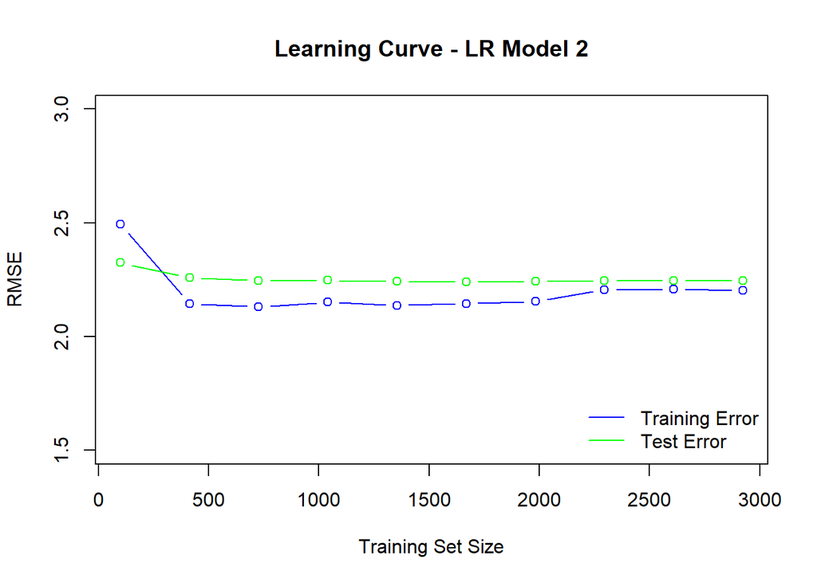

```r
te_errs = c()
tr_errs = c()
te_actual = te_dat$Age
tr_sizes = seq(100, nrow(tr_dat), length.out=10)


for (tr_size in tr_sizes) {
  tr_dat1 = tr_dat[1:tr_size,]
  tr_actual = tr_dat1$Age
  fit = lm(Age ~ Diameter + Height + Weight_W + Weight_Shk + Weight_V + Weight_Shl, data=tr_dat1)

  # error on training set
  tr_predicted = predict(fit, tr_dat1)
  err = sqrt(mean((tr_actual-tr_predicted)^2))
  tr_errs = c(tr_errs, err)

  # error on test set
  te_predicted = predict(fit, te_dat)
  err = sqrt(mean((te_actual-te_predicted)^2))
  te_errs = c(te_errs, err)
}

plot(tr_sizes, tr_errs,  col="blue", main= "Learning Curve - LR Model 2", type="b",ylim=c(1.5,3), ylab = "RMSE", xlab = "Training Set Size")
lines(tr_sizes,te_errs, col="green", type="b", xlab = "Training Set Size")
legend("bottomright", c("Training Error","Test Error"), col= c("blue","green"), lty=1,bty="n")
```

## Model 3

For this third and final linear regression model, we will take the features that are easiest to apply in the field when taking measurements from the Abalone.

```r
fit3_lm = lm(Age ~ Diameter + Height + Weight_W, data=tr_dat)
```

Next we will generate the predictions from our new model and calculate the RMSE value for it.

```r
predicted3 <- predict(fit3_lm, te_dat)
actual <- te_dat$Age

rmse3 = sqrt(mean((actual - predicted3)^2))
```

### Diagnostic Plots

#### Cross Validation

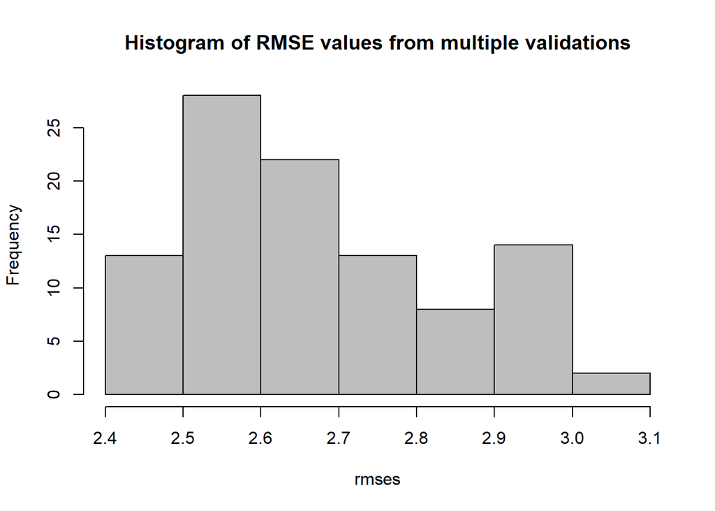

```r
rmses = c()
for (i in 1:100) {
  dsets = split_data(dat, c(2, 1, 1))
  train_dat = dsets[[1]]
  valid_dat = dsets[[2]]

  fit = lm(Age ~ Diameter + Height + Weight_W, data=train_dat)

  predicted <- predict(fit, valid_dat)
  actual <- valid_dat$Age
  rmse <- sqrt(mean((actual - predicted)^2))

  rmses = c(rmses, rmse)
}

hist(rmses, col="grey", main="Histogram of RMSE values from multiple validations")
```

Comparing this plot to the cross validation plot from the base model and the second model, we can see that this third plot has a different the range of RMSE values than the other two. However, like the base model, the RMSE values are mostly spread out across the range with a peak at 2.5 to 2.6.